# project1_thanhvu

2025-10-16

https://data.pa.gov/Covid-19/COVID-19-Vaccinations-by-Age-Group-Current-County-/niuh-2xe3/data_preview

How well do vaccination rates in younger age groups (20-24, 25-29, 30-34) predict vaccination rates in the 35-39 age group across Pennsylvania counties?

```r
library(readr)
library(ggplot2)
library(GGally)
library(car)
library(tidyverse)
library(ggfortify)
library(nortest)
```

```r
covid_data <- read_csv("C:/mat374/COVID-19_Vaccinations_by_Age_Group_Current_County_Health_20251015.csv")
```

```r
# Create total young vaccination variable
covid_clean <- covid_data %>%
  rename(
    County = `County Name`,
    Age_20_24 = `Partially Covered Age Group 20-24`,
    Age_25_29 = `Partially Covered Age Group 25-29`,
    Age_30_34 = `Partially Covered Age Group 30-34`,
    Age_35_39 = `Partially Covered Age Group 35-39`
  )
```

Scatterplot matrix to examine relationships

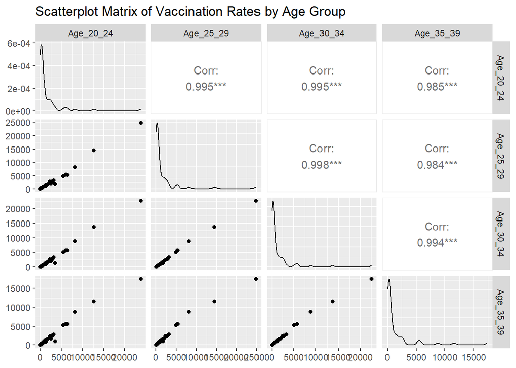

```r
ggpairs(covid_clean[, c("Age_20_24", "Age_25_29", "Age_30_34", "Age_35_39")]) +
  labs(title = "Scatterplot Matrix of Vaccination Rates by Age Group")
```

Multiple Regression Model

Model Fitting

```r
covid_lm <- lm(Age_35_39 ~ Age_20_24 + Age_25_29 + Age_30_34, data = covid_clean)
summary(covid_lm)
```

```
##
## Call:
## lm(formula = Age_35_39 ~ Age_20_24 + Age_25_29 + Age_30_34, data = covid_clean)
##
## Residuals:
##     Min      1Q  Median      3Q     Max
## -370.82  -39.45   -7.98   29.77  543.19
##
## Coefficients:
##             Estimate Std. Error t value Pr(>|t|)
## (Intercept) 13.98137   16.52118   0.846    0.401
## Age_20_24    0.06714    0.04261   1.576    0.120
## Age_25_29   -1.25632    0.06307 -19.920   <2e-16 ***
## Age_30_34    2.09058    0.06422  32.554   <2e-16 ***
## ---
## Signif. codes:  0 '***' 0.001 '**' 0.01 '*' 0.05 '.' 0.1 ' ' 1
##
## Residual standard error: 115.5 on 63 degrees of freedom
## Multiple R-squared:  0.9984, Adjusted R-squared:  0.9984
## F-statistic: 1.334e+04 on 3 and 63 DF,  p-value: < 2.2e-16
```

Model Summary R-squared: 0.9984 (99.84% of variance explained)

F-statistic: 13340 (p < 0.001)

Residual standard error: 115.5

Coefficient Interpretation Age_20_24: Not significant (p = 0.120)

Age_25_29: Strong negative effect (β = -1.256, p < 0.001)

Age_30_34: Strong positive effect (β = 2.091, p < 0.001)

Diagnostic Plots

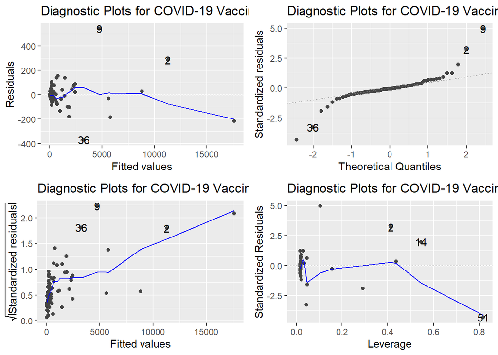

```r
autoplot(covid_lm) +
  labs(title = "Diagnostic Plots for COVID-19 Vaccination Model")
```

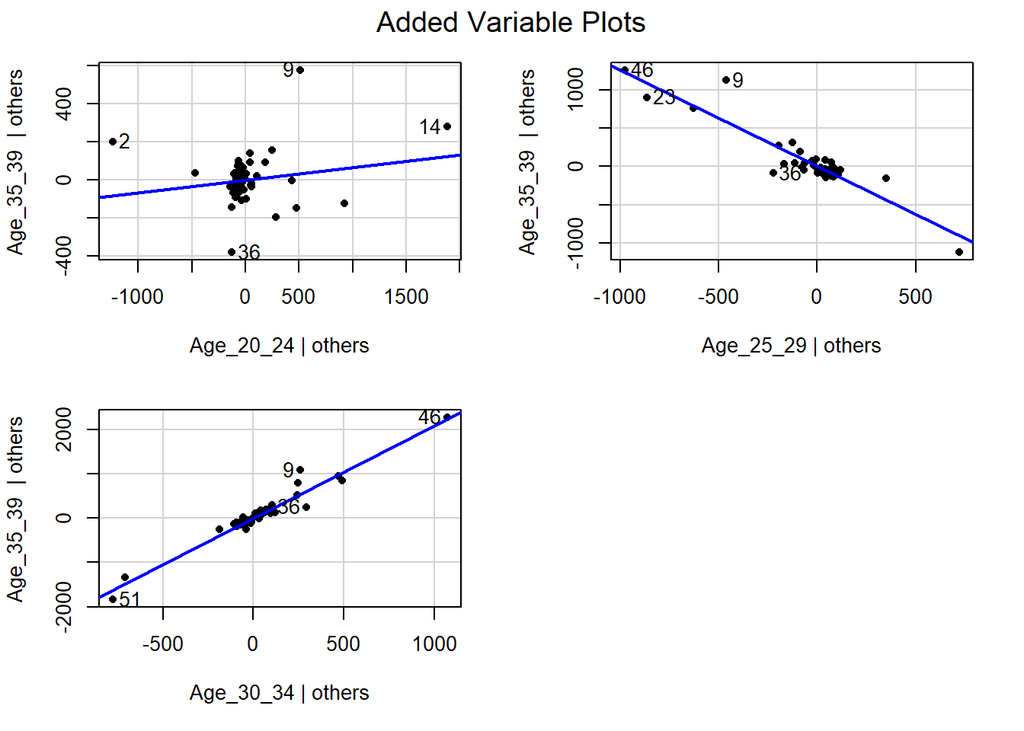

```r
avPlots(covid_lm, pch = 16, main = "Added Variable Plots")
```

Residuals vs Fitted: Shows some curvature and potential heteroscedasticity, suggesting the linearity assumption may be violated

Normal Q-Q Plot: Residuals deviate from normality, especially in the tails

Scale-Location Plot: Slight funnel pattern indicates potential non-constant variance

Standardized Residuals vs Predictors

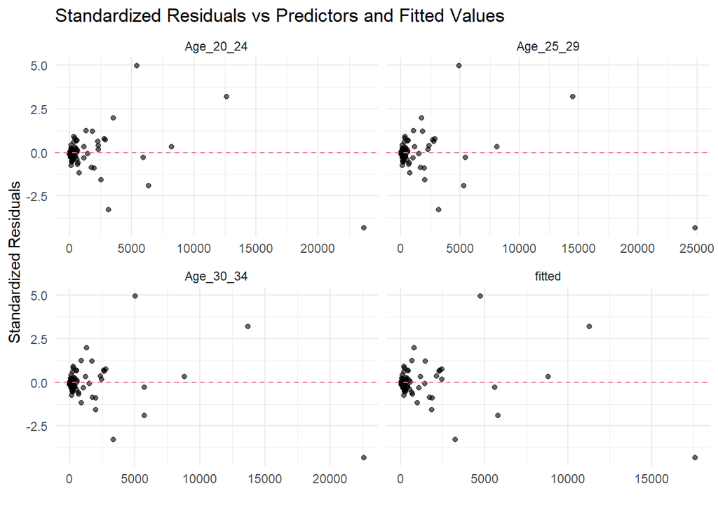

```r
diag_df <- covid_clean %>%
  mutate(
    fitted = fitted(covid_lm),
    std_resid = rstandard(covid_lm)
  )

diag_df %>%
  pivot_longer(cols = c(Age_20_24, Age_25_29, Age_30_34, fitted),
               names_to = "variable", values_to = "xval") %>%
  ggplot(aes(x = xval, y = std_resid)) +
  geom_point(alpha = 0.6) +
  geom_hline(yintercept = 0, color = "hotpink2", linetype = "dashed") +
  facet_wrap(~ variable, scales = "free_x") +
  labs(x = "", y = "Standardized Residuals",
       title = "Standardized Residuals vs Predictors and Fitted Values") +
  theme_minimal()
```

Formal Normality Tests

```r
res <- residuals(covid_lm)

ad_test <- ad.test(res)
ad_test
```

```
##
##  Anderson-Darling normality test
##
## data:  res
## A = 2.9245, p-value = 1.981e-07
```

```r
shapiro_test <- shapiro.test(res)
shapiro_test
```

```
##
##  Shapiro-Wilk normality test
##
## data:  res
## W = 0.83494, p-value = 3.669e-07
```

```r
lillie_test <- lillie.test(res)
lillie_test
```

```
##
##  Lilliefors (Kolmogorov-Smirnov) normality test
##
## data:  res
## D = 0.15084, p-value = 0.0006514
```

Formal Normality Test Results All three formal normality tests provide strong evidence against the normality assumption:

Anderson-Darling Test: A = 2.9245, p-value = 1.981e-07

Shapiro-Wilk Test: W = 0.83494, p-value = 3.669e-07

Lilliefors Test: D = 0.15084, p-value = 0.0006514

All p-values are well below 0.05, providing conclusive evidence that the residuals do not follow a normal distribution.

Make prediction

```r
example_county <- data.frame(
  Age_20_24 = 1000,
  Age_25_29 = 1200,
  Age_30_34 = 1100
)
pred_interval <- predict(covid_lm, newdata = example_county, interval = "prediction")
pred_interval
```

```
##        fit      lwr      upr
## 1 873.1818 639.5402 1106.823
```

For a county with 1,000 (20-24), 1,200 (25-29), and 1,100 (30-34) vaccinations, predicted 35-39 vaccination count = 873.18 (95% PI: 639.54 to 1106.82)

Research Question & Dataset Analyzed how younger age group vaccination rates predict 35-39 age group rates across 67 Pennsylvania counties using COVID-19 vaccination data.

Variables & Model Response: Age_35_39 vaccination count Predictors: Age_20_24, Age_25_29, Age_30_34 vaccination counts Model: Multiple linear regression

Key Findings High R-squared (99.84%) but severe assumption violations

Age_30_34 strongest positive predictor

Age_25_29 shows counterintuitive negative relationship

Age_20_24 not significant

Non-normal errors

Non-constant variance

Counterintuitive coefficient for Age_25_29

Conclusion Despite high R-squared, the model violates critical assumptions and should not be used for inference.Consider alternative methods like data transformations